# Updates to Word Vector Utilities

James Clawson

2020-08-27

A year of using and fiddling with [`w2v_utilities`](https://gist.github.com/jmclawson/21c6a40c78fd66d708bec45d5c0b52e2) has led to more improvements in functionality and display than I expected. While a [previous post](https://jmclawson.net/blog/posts/word-vector-utilities) explains the ways to use available functions, this post explains some of the changes to `cosine_heatmap()` and introduces new visualizations with `cosine_bars()`.

These visualizations show images using the older code. Because it’s a way to compare and see the improvements, I’ve left things to stand as they are.

## Changes in heatmap visualization

Now, by default, column titles displayed by `cosine_heatmap()` will show at the top, and the “first” row will always be the row closest to the column titles. To clean up presentation the zero digit before the decimal point has been omitted, and all values show the same number of digits after the decimal point (rather than dropping a final zero). Additionally, the viridis color scheme has been adopted for its accessibility for different forms of colorblindedness, its printability, and—subjectively speaking—attractiveness.

As bonus, viridis comes with some [nice palette options](https://cran.r-project.org/web/packages/viridis/vignettes/intro-to-viridis.html).

As a change from the previous version, the code to make a similarity matrix is now separated from the code to make a heatmap, so those parameters should come first. Either save the similarity matrix, or pipe it directly into the function for `cosine_heatmap()`.

By default, the heatmap shows values overlaid on corresponding colors. Set `alpha` between 0 and 1 to adjust the intensity of the background.

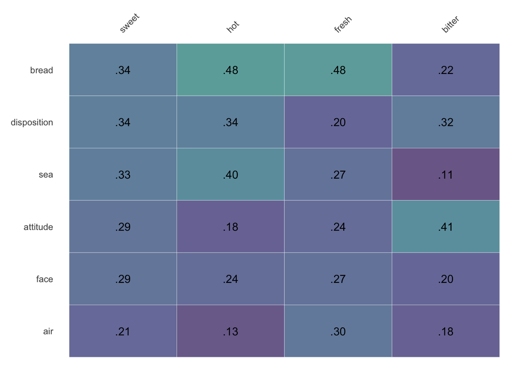

Setting `values` to `FALSE` toggles on the legend; since legibility against text labels isn’t an issue, it also makes colors more vibrant by setting `alpha=1`.

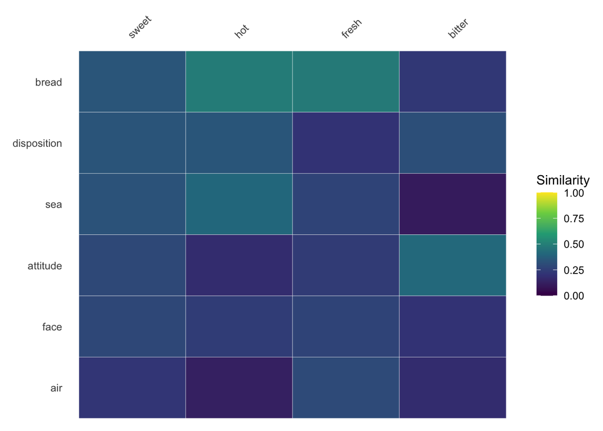

Choose different color palettes using the `colorset` option. This comparison shows (A) `colorsets = 'magma'`, (B) `colorsets = 'plasma'`, (C) `colorsets = 'inferno'`, and (D) `colorsets = 'cividis'`.

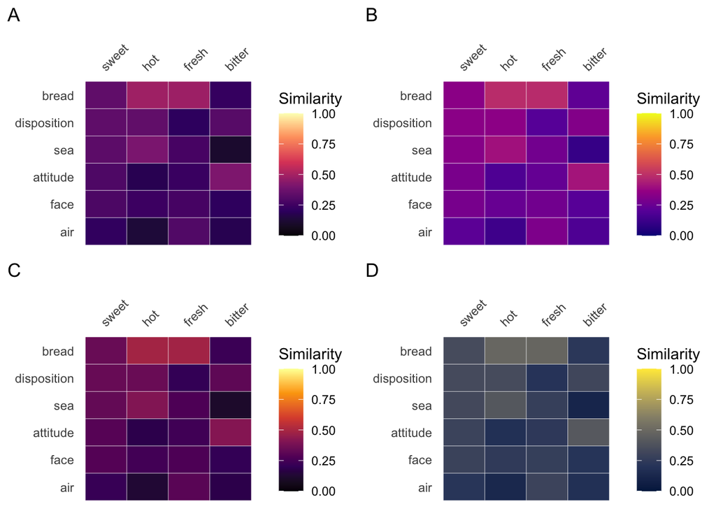

The previous color palette is available by setting `colorset='red'`.

[figure not shown]

```r
make_siml_matrix(WomensNovels,
                 x = c("sweet", "bitter",
                       "fresh", "hot"),
                 y = c("air", "attitude",
                       "bread", "disposition",
                       "face", "sea")) %>%
  cosine_heatmap()
```

You might notice that the heatmap is minimally styled compared to the previous output, lacking a title and other options. It’s easy to add these other details using standard `ggplot2` notation and functions like `labs()`.

Heatmaps hiding redundant information will flip the placement of column headers so that these are shown near the data:

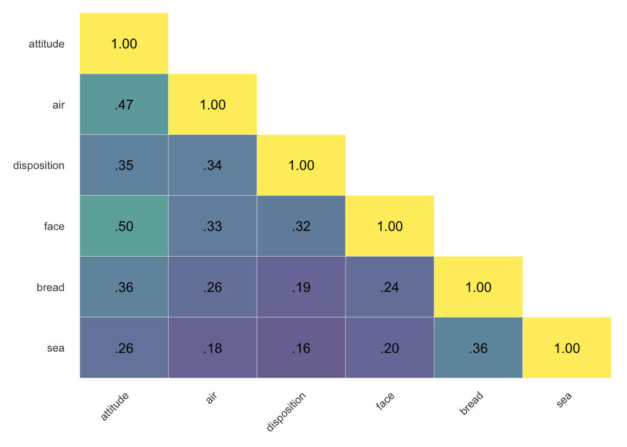

```r
make_siml_matrix(WomensNovels,
                 x = c("air", "attitude",
                       "bread", "disposition",
                       "face", "sea"),
                 y = c("air", "attitude",
                       "bread", "disposition",
                       "face", "sea")) %>%
  cosine_heatmap(redundant = FALSE)
```

## Changes in heatmap function

In addition to changes in theming and calling the function, a few options have been added, along with new defaults related to them.

### `sort.y` and `sort.x` (both default to `TRUE`)

It can be easier to read an exploratory heatmap like this when the terms are arranged in some understandable way. And since outliers can throw off averages, it makes the most sense to arrange things by median values. Rows are ordered by their median values with `sort.y=TRUE`, and order columns with `sort.x=TRUE`, but these options can be turned off by setting the options to `FALSE`:

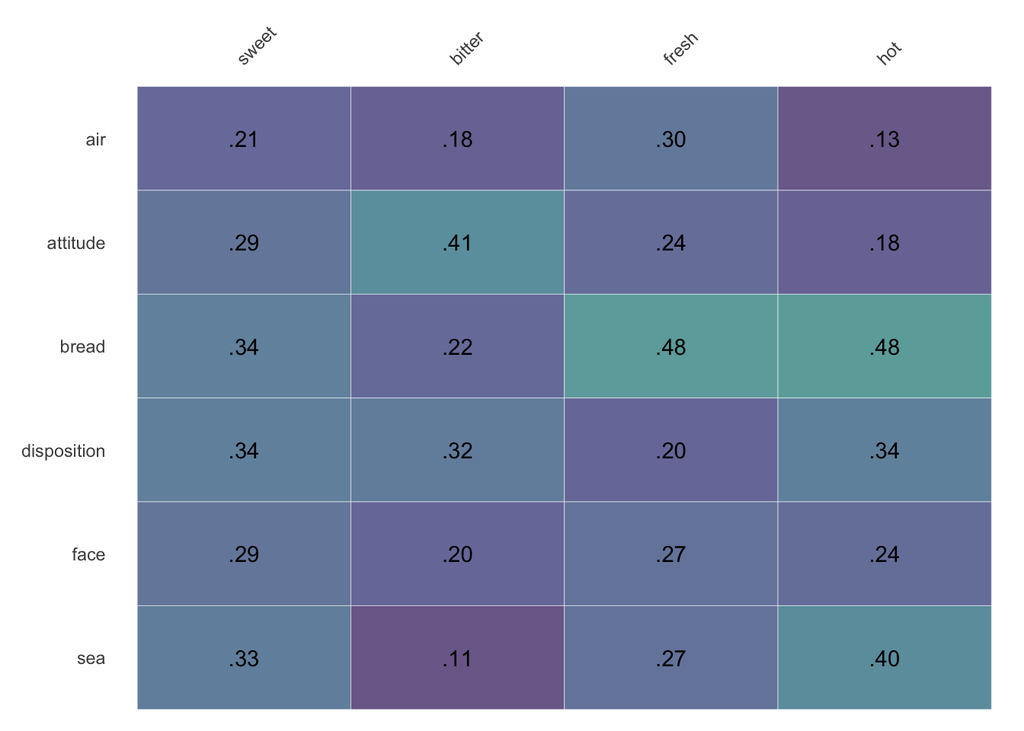

```r
make_siml_matrix(WomensNovels,
                 x = c("sweet", "bitter",
                     "fresh", "hot"),
                 y = c("air", "attitude",
                     "bread", "disposition",
                     "face", "sea")) %>%
  cosine_heatmap(sort.y = FALSE,
                 sort.x = FALSE)
```

In many cases, you’ll want to keep one of the axes stable, ordered manually or set by something other than values in the matrix. Because of the underlying order of things in the code, if it makes more sense to think of one vector as stable, make it the columns or x-values, with `sort.y` toggled to `TRUE` and `sort.x` to `FALSE`.

For example, if you’re certain about the terms that can be found in one vector and would like to preserve their order as determined by their nearness to each other, rather than by their nearness to another vector.

### `limit.y` or `limit.x`

Limit the rows to the top 10 (or some other number) by setting `limit.y=10`. By expanding the row definition to find more words along a vector (using `closest_to()` with higher values of `n`), sorting these items by their median cosine similarity to words in the columns (by setting `sort.y=TRUE`), and then limiting to a subset of rows (with `limit.y`), you can easily explore strong relationships you might not otherwise have considered.

Starting from only as many terms as you hope to show in the end can limit discovery of any unexpected interactions between the vectors.

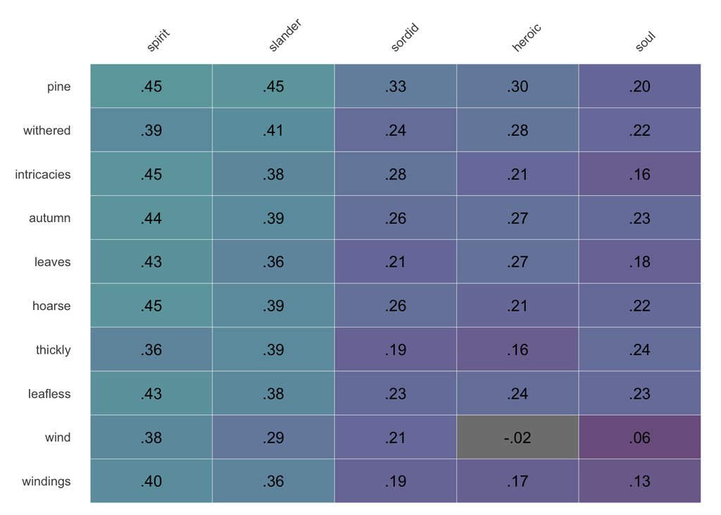

```r
make_siml_matrix(WomensNovels,
  x = closest_to(WomensNovels,
                 ~"soul" + "spirit",
                 n = 5)$word,
  y = closest_to(WomensNovels,
                 ~"wind" + "leaves",
                 n = 10)$word) %>%
  cosine_heatmap()
```

By finding 50 rows, ordering them, and then limiting them to the top 10, you’re able to find words that are closer to the words in the columns.

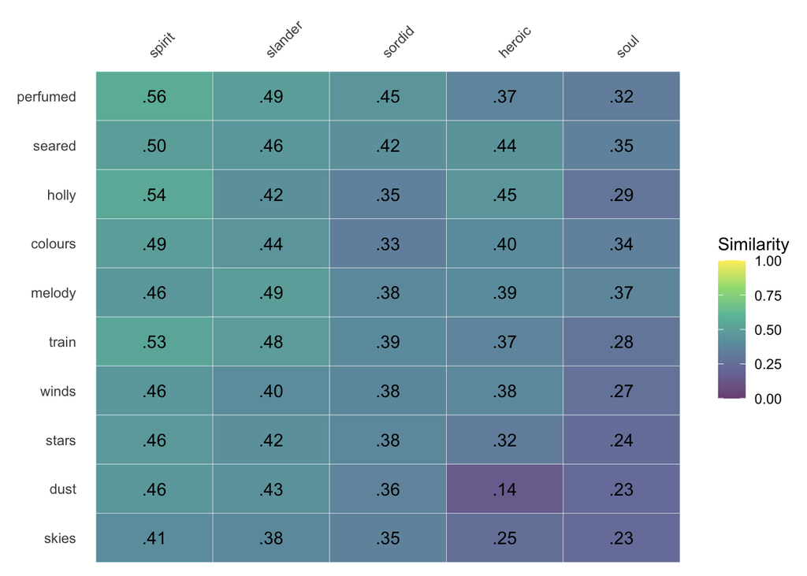

```r
make_siml_matrix(WomensNovels,
  x = closest_to(WomensNovels,
                 ~"soul" + "spirit",
                 n = 5)$word,
  y = closest_to(WomensNovels,
                 ~"wind" + "leaves",
                 n = 50)$word) %>%
  cosine_heatmap(limit.y = 10, legend = TRUE)
```

The same mechanism exists for limiting columns using `limit.x`, but using these two options together will yield a matrix of terms quite far from those you started with. Moreover, as the order of steps for sorting and limiting starts with rows, the final choice of columns may not appear to correlate with the ordering of rows by median.

Using both limits together isn’t very useful. Over optimizing tends to yield a matrix of terms too far from the starting point.

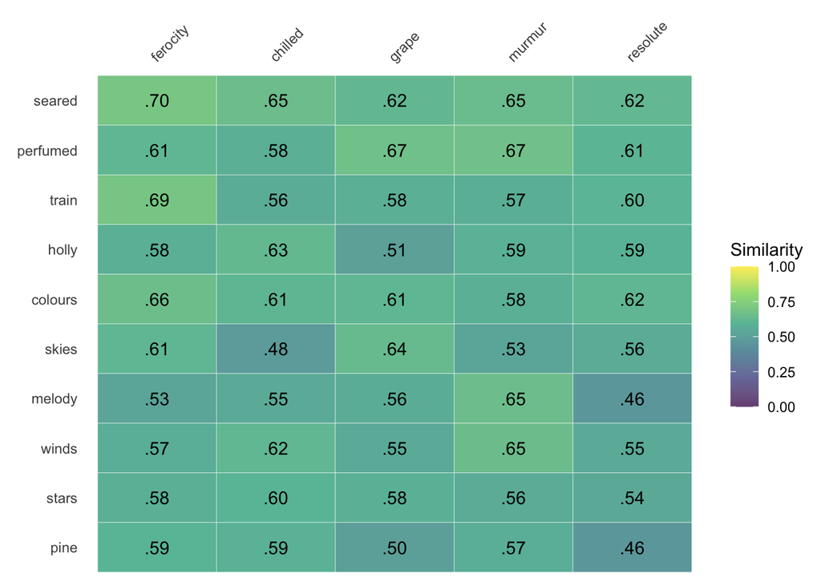

```r
make_siml_matrix(WomensNovels,
  x = closest_to(WomensNovels,
                 ~"soul" + "spirit",
                 n = 50)$word,
  y = closest_to(WomensNovels,
                 ~"wind" + "leaves",
                 n = 50)$word) %>%
  cosine_heatmap(limit.y = 10, limit.x = 5,
                 legend = TRUE)
```

### `top.down`

If you would prefer to keep the column titles at the bottom of the heatmap, use `top.down=FALSE` to revert to this earlier version—while still retaining other visual changes, including the ordering of rows starting with those nearest column headers.

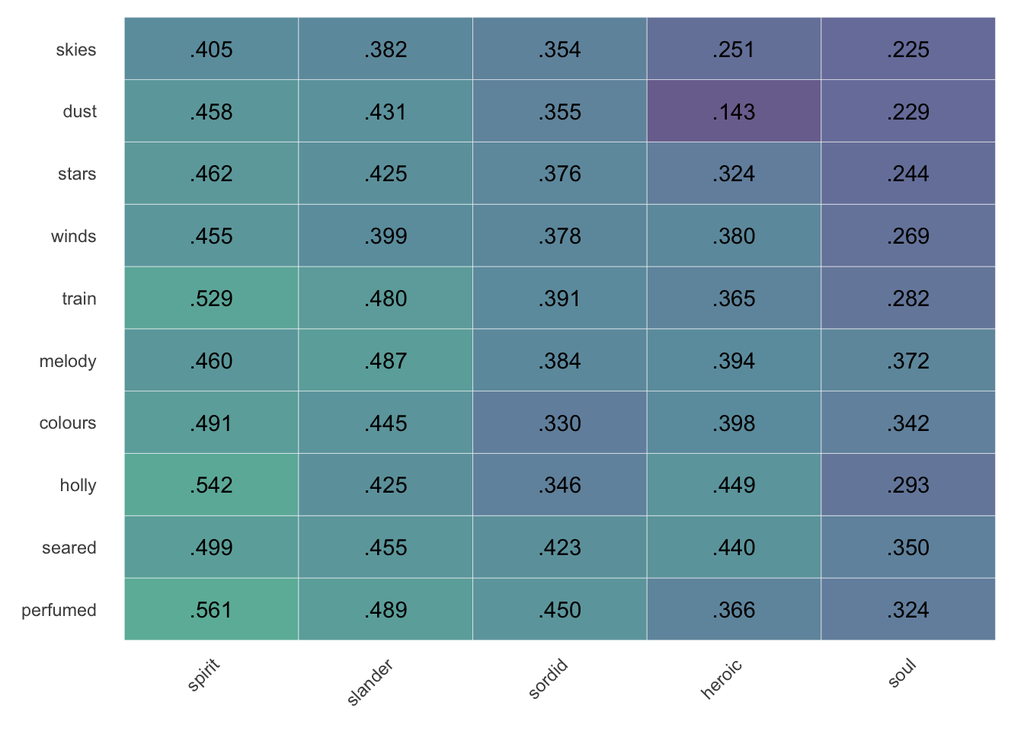

```r
make_siml_matrix(WomensNovels,
  x = closest_to(WomensNovels,
                 ~"soul" + "spirit",
                 n = 5)$word,
  y = closest_to(WomensNovels,
                 ~"wind" + "leaves",
                 n = 50)$word) %>%
  cosine_heatmap(round = 3,
                 limit.y = 10,
                 top.down = FALSE)
```

### `amplify`

Finally, to bring these options in line with amplified heat maps, I pulled the latter function into `cosine_heatmap()` as an option, rather than as its own function. This option also maintains the earlier red/blue color palette. To use the option, set `amplify=TRUE`.

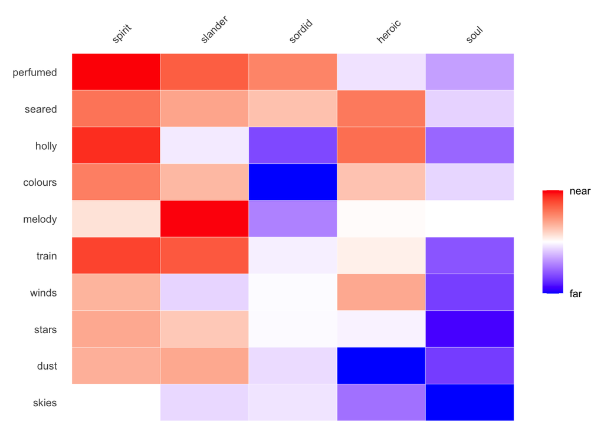

```r
make_siml_matrix(WomensNovels,
  x = closest_to(WomensNovels,
               ~"soul" + "spirit",
               n = 5)$word,
  y = closest_to(WomensNovels,
               ~"wind" + "leaves",
               n = 50)$word) %>%
  cosine_heatmap(limit.y = 10,
                 amplify=TRUE)
```

If you’d like to add an additional step of re-arranging this amplified heatmap, so that lower rows and columns are nearer each other based on their amplified values, set `sort.twice=TRUE`.

Setting `sort.twice=TRUE` might not be a good idea, since it sorts terms based on abstract values, rather than actual cosine similarity. Be wary using it with amplified heatmaps.

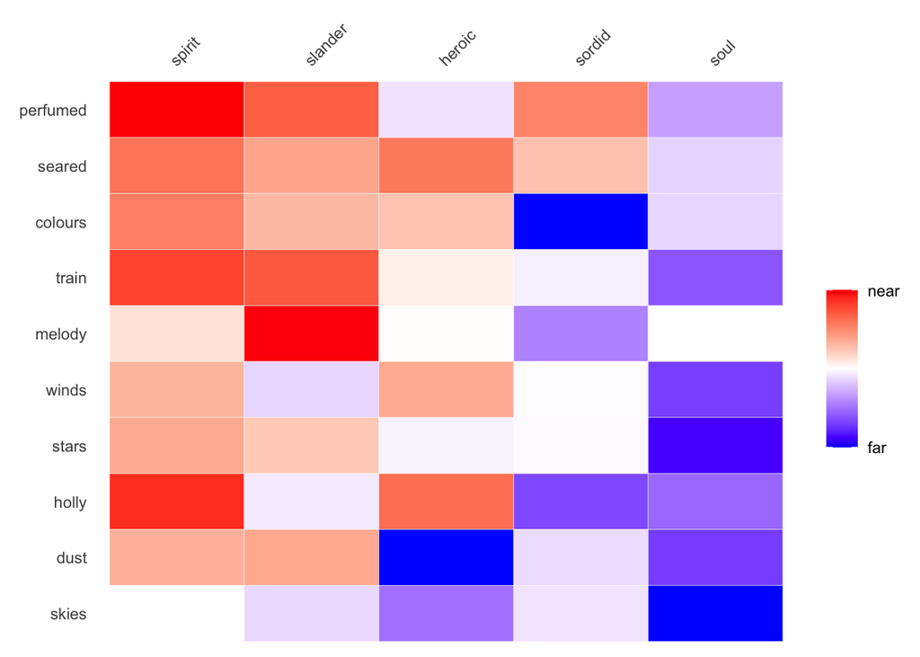

```r
make_siml_matrix(WomensNovels,
  x = closest_to(WomensNovels,
                 ~"soul" + "spirit",
                 n = 5)$word,
  y = closest_to(WomensNovels,
                 ~"wind" + "leaves",
                 n = 50)$word) %>%
  cosine_heatmap(limit.y = 10,
                 sort.twice = TRUE,
                 amplify=TRUE)
```

## New visualizations with bar charts

Heatmaps are useful for showing two-dimensional comparisons, but many explorations of word embeddings are interested in proximity of terms along a vector in one dimension. Bar charts are better suited for these one-dimensional comparisons.

### Showing similarity to one dimension

A new function, `cosine_bars()` interfaces directly with `word2vec`’s function `closest_to()` to turn values into easily readable bar charts:

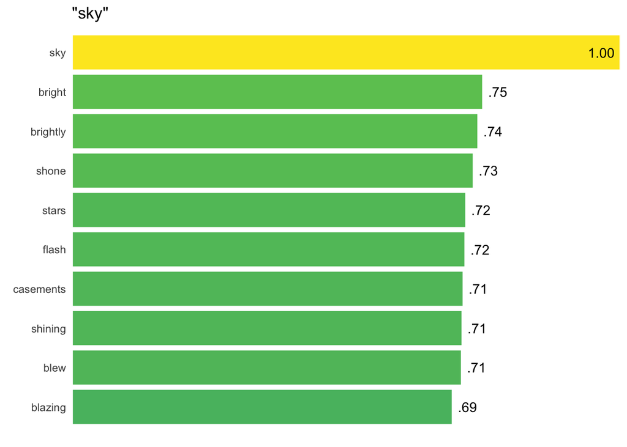

```r
closest_to(WomensNovels, "sky") %>%
  cosine_bars()
```

The title of the chart shows the query used, and similarity values over 0.9 display inside the bar to avoid clipping at the right edge:

Add axis labels using standard `ggplot2` functions, but note that axes have been flipped.

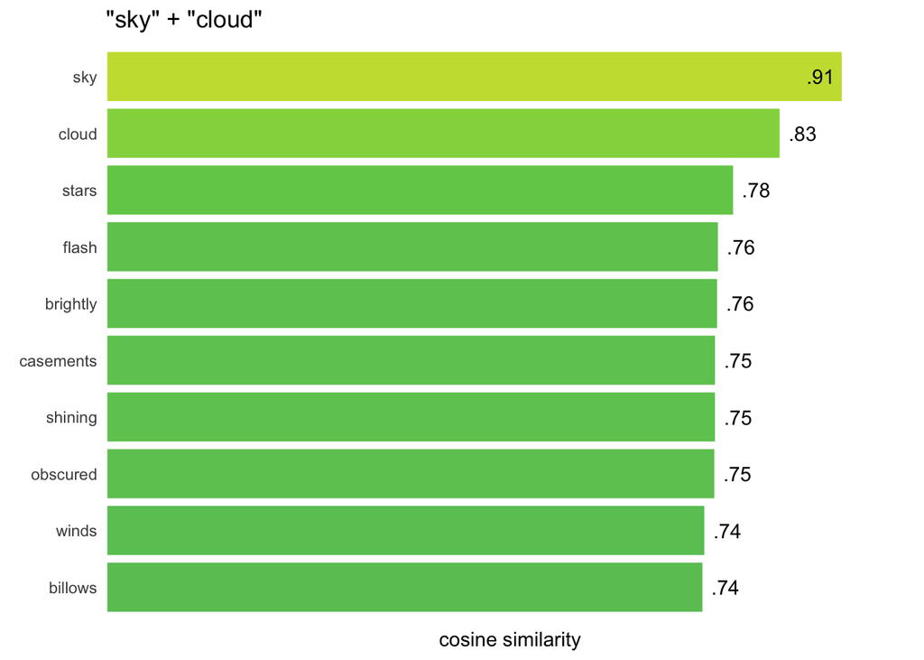

```r
closest_to(WomensNovels, ~"sky" + "cloud") %>%
  cosine_bars() +
  labs(y="cosine similarity")
```

### Comparing similarities in many dimensions

It also accepts two-dimensional matrices to display a comparative set of small multiples:

```r
make_siml_matrix(WomensNovels,
      closest_to(WomensNovels,"dog")$word,
      closest_to(WomensNovels,"sky")$word) %>%
  cosine_bars()
```

As with heatmaps, these bar charts default to organizing rows and groups by median values, with higher medians charted first. The same `sort.x` and `sort.y` options can disable this feature.

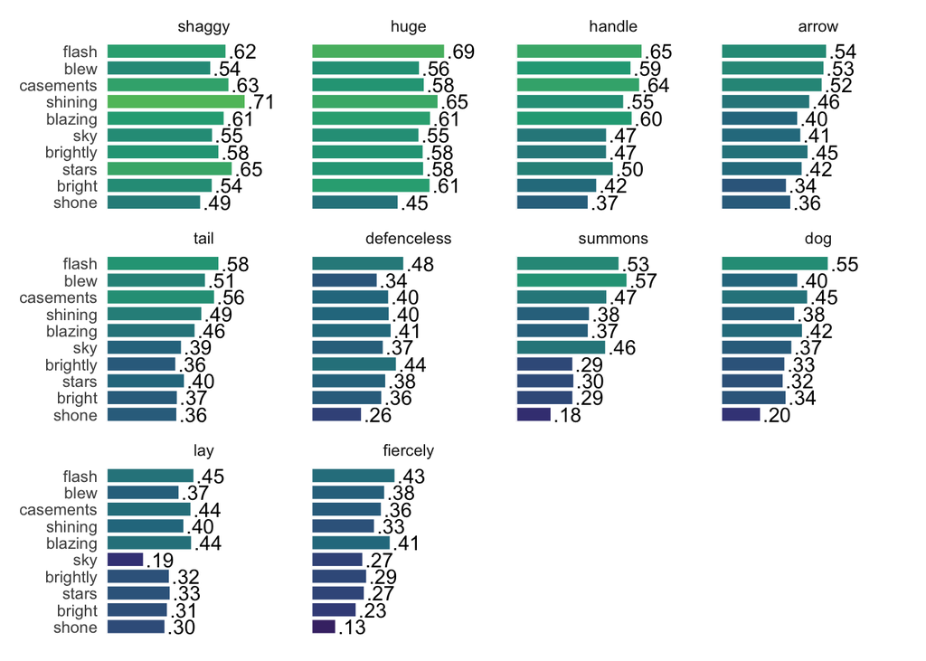

By default, these charts set a maximum width of 1, so that every visualization output with the same dimensions will be comparable and to force white space for showing values. This option can be toggled off by setting `force.width=FALSE`, which sets the width to the maximum of the set:

```r
make_siml_matrix(WomensNovels,
      closest_to(WomensNovels,"fish")$word,
      closest_to(WomensNovels,"sky")$word) %>%
  cosine_bars(force.width = FALSE)
```

Setting `force.width = FALSE` stretches bars to take up the whole width of the space, but it also increases the likelihood that higher values get clipped.

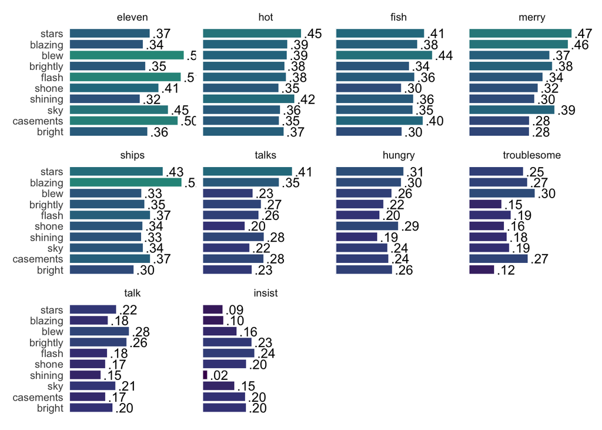

## …

I used these updated functions, along with a few others I’m still modifying, to explore the models I worked with for this blog post over there.